# course_project

Chiang

20160515

## Synopsis

In this report I tried to predict the [testing data](http://d396qusza40orc.cloudfront.net/predmachlearn/pml-testing.csv) using the basic decision tree and random forest algorithm built upon the [training data](http://d396qusza40orc.cloudfront.net/predmachlearn/pml-training.csv). Considering accuracy of basic `decision trees` and `random forests` on training data, I select random forest as the algorithm being used to predict, which has an expected error rate of `0.0023` . The result of prediction is shown at the end of the report.

## settings

I tried to use method `rf` in `caret` package, but it took too long for training. Package `randomForest` is thus chosen to supplant.

## Getting and cleaning the data

download the data

```r
trainUrl <- "http://d396qusza40orc.cloudfront.net/predmachlearn/pml-training.csv"
testUrl <- "http://d396qusza40orc.cloudfront.net/predmachlearn/pml-testing.csv"

training <- read.csv(url(trainUrl), na.strings=c("NA","#DIV/0!",""))
testing <- read.csv(url(testUrl), na.strings=c("NA","#DIV/0!",""))
```

split the training set at a 6:4 proportion

```r
inTrain <- createDataPartition(training$classe, p=0.6, list=FALSE)
myTraining <- training[inTrain, ]
myTesting <- training[-inTrain, ]
```

Remove NearZeroVariance and not meaningful variables

```r
nzv <- nearZeroVar(myTraining, saveMetrics=TRUE)
myTraining <- myTraining[,nzv$nzv==FALSE]
nzv<- nearZeroVar(myTesting,saveMetrics=TRUE)
myTesting <- myTesting[,nzv$nzv==FALSE]
myTraining <- myTraining[c(-1)]
```

Set an additional threshold of 50% NA to decide whether a variable is to be eliminated, apply to splitted training data sets.

```r
trainingV3 <- myTraining
for(i in 1:length(myTraining)) {
    if( sum( is.na( myTraining[, i] ) ) /nrow(myTraining) >= .5) {
        for(j in 1:length(trainingV3)) {
            if( length( grep(names(myTraining[i]), names(trainingV3)[j]) ) == 1)  {
                trainingV3 <- trainingV3[ , -j]
            }
        }
    }
}

myTraining <- trainingV3
rm(trainingV3)

clean1 <- colnames(myTraining)
clean2 <- colnames(myTraining[, -58])  # remove the classe column
myTesting <- myTesting[clean1]
testing <- testing[clean2]

for (i in 1:length(testing) ) {
  for(j in 1:length(myTraining)) {
    if( length( grep(names(myTraining[i]), names(testing)[j]) ) == 1)  {
      class(testing[j]) <- class(myTraining[i])
    }
  }
}

testing <- rbind(myTraining[2, -58] , testing)
testing <- testing[-1,]
```

## Decision Trees

[figure not shown]

```r
set.seed(10000)
dt <- rpart(classe ~ ., data=myTraining, method="class")
fancyRpartPlot(dt)
```

```r
pdt <- predict(dt, myTesting, type = "class")

confusionMatrix(pdt, myTesting$classe)
```

```
## Confusion Matrix and Statistics
##
##           Reference
## Prediction    A    B    C    D    E
##          A 2151  201    3    1    0
##          B   46 1133   88   60    0
##          C   35  178 1259  196    2
##          D    0    6   16  884   92
##          E    0    0    2  145 1348
##
## Overall Statistics
##
##                Accuracy : 0.8635
##                  95% CI : (0.8557, 0.871)
##     No Information Rate : 0.2845
##     P-Value [Acc > NIR] : < 2.2e-16
##
##                   Kappa : 0.827
##  Mcnemar's Test P-Value : NA
##
## Statistics by Class:
##
##                      Class: A Class: B Class: C Class: D Class: E
## Sensitivity            0.9637   0.7464   0.9203   0.6874   0.9348
## Specificity            0.9635   0.9693   0.9366   0.9826   0.9770
## Pos Pred Value         0.9130   0.8538   0.7539   0.8858   0.9017
## Neg Pred Value         0.9852   0.9409   0.9824   0.9413   0.9852
## Prevalence             0.2845   0.1935   0.1744   0.1639   0.1838
## Detection Rate         0.2742   0.1444   0.1605   0.1127   0.1718
## Detection Prevalence   0.3003   0.1691   0.2128   0.1272   0.1905
## Balanced Accuracy      0.9636   0.8579   0.9284   0.8350   0.9559
```

## Random Forests

```r
rf <- randomForest(classe ~ ., data=myTraining)
prf <- predict(rf, myTesting, type = "class")
confusionMatrix(prf, myTesting$classe)
```

```
## Confusion Matrix and Statistics
##
##           Reference
## Prediction    A    B    C    D    E
##          A 2231    1    0    0    0
##          B    1 1517    5    0    0
##          C    0    0 1359    3    0
##          D    0    0    4 1282    3
##          E    0    0    0    1 1439
##
## Overall Statistics
##
##                Accuracy : 0.9977
##                  95% CI : (0.9964, 0.9986)
##     No Information Rate : 0.2845
##     P-Value [Acc > NIR] : < 2.2e-16
##
##                   Kappa : 0.9971
##  Mcnemar's Test P-Value : NA
##
## Statistics by Class:
##
##                      Class: A Class: B Class: C Class: D Class: E
## Sensitivity            0.9996   0.9993   0.9934   0.9969   0.9979
## Specificity            0.9998   0.9991   0.9995   0.9989   0.9998
## Pos Pred Value         0.9996   0.9961   0.9978   0.9946   0.9993
## Neg Pred Value         0.9998   0.9998   0.9986   0.9994   0.9995
## Prevalence             0.2845   0.1935   0.1744   0.1639   0.1838
## Detection Rate         0.2843   0.1933   0.1732   0.1634   0.1834
## Detection Prevalence   0.2845   0.1941   0.1736   0.1643   0.1835
## Balanced Accuracy      0.9997   0.9992   0.9965   0.9979   0.9989
```

## Expected error

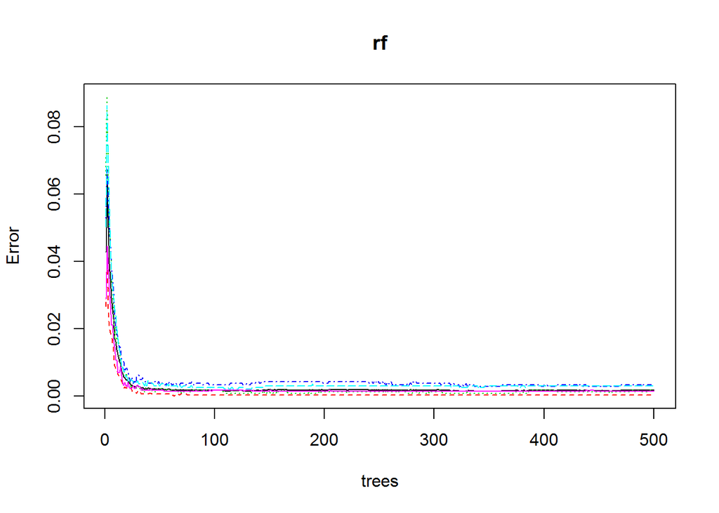

```r
plot(rf)
```

The expected errors converge to `1`-`0.9977` = `0.0023`

# Predicting Results on the Test Data

According to the prominently better performance, the Random Forest algorithm is selected to predict the testing set as shown below.

```r
prediction <- predict(rf, testing, type = "class")
prediction
```

```
##  2 31  4  5  6  7  8  9 10 11 12 13 14 15 16 17 18 19 20 21
##  B  A  B  A  A  E  D  B  A  A  B  C  B  A  E  E  A  B  B  B
## Levels: A B C D E
```